# Actividad - Proyecto práctico

> La actividad se desarrollará en grupos pre-definidos de 4 alumnos. Se debe indicar los nombres en orden alfabético (de apellidos). Recordad que esta actividad se corresponde con un 30% de la nota final de la asignatura. Se debe entregar entregar el trabajo en la presente notebook.
- Alumno 1: Rosa Ines Chamorro Nieto
- Alumno 2: Lucia Sanjuan Pérez
- Alumno 3: Ander Amatriain Amiano
- Alumno 4:

## **PARTE 1** - Instalación y requisitos previos

> Las prácticas han sido preparadas para poder realizarse en el entorno de trabajo de Google Colab. Sin embargo, esta plataforma presenta ciertas incompatibilidades a la hora de visualizar la renderización en gym. Por ello, para obtener estas visualizaciones, se deberá trasladar el entorno de trabajo a local. Por ello, el presente dosier presenta instrucciones para poder trabajar en ambos entornos. Siga los siguientes pasos para un correcto funcionamiento:
1. **LOCAL:** Preparar el enviroment, siguiendo las intrucciones detalladas en la sección *1.1.Preparar enviroment*.
2. **AMBOS:** Modificar las variables "mount" y "drive_mount" a la carpeta de trabajo en drive en el caso de estar en Colab, y ejecturar la celda *1.2.Localizar entorno de trabajo*.
3. **COLAB:** se deberá ejecutar las celdas correspondientes al montaje de la carpeta de trabajo en Drive. Esta corresponde a la sección *1.3.Montar carpeta de datos local*.
4. **AMBOS:** Instalar las librerías necesarias, siguiendo la sección *1.4.Instalar librerías necesarias*.

### 1.1. Preparar enviroment (solo local)

1. En Windows, puede ser necesario instalar las C++ Build Tools. Para ello, siga los siguientes pasos. Alternativamente puedes utilizar WSL2: https://towardsdatascience.com/how-to-install-openai-gym-in-a-windows-environment-338969e24d30.
2. Instalar Anaconda
3. Siguiendo el código que se presenta comentado en la próxima celda: Crear un enviroment, cambiar la ruta de trabajo, e instalar librerías básicas.

> Para preparar el entorno de trabajo en local, se han seguido los siguientes pasos:

```
conda create --name miar_rl python=3.8
conda activate miar_rl
cd "PATH_TO_FOLDER"
conda install git
pip install jupyter
```

4. Abrir la notebook con *jupyter-notebook*.

```
jupyter-notebook
```

### 1.2. Localizar entorno de trabajo: Google colab o local

```python
# ATENCIÓN!! Modificar ruta relativa a la práctica si es distinta (drive_root)
mount='/content/gdrive'
drive_root = mount + "/My Drive/Estudios/Master Inteligencia Artificial/08MIAR - Aprendizaje por refuerzo/Proyecto Practico"

try:
  from google.colab import drive
  IN_COLAB=True
except:
  IN_COLAB=False
```

### 1.3. Montar carpeta de datos local (solo Colab)

```python
# Switch to the directory on the Google Drive that you want to use
import os
if IN_COLAB:
  print("We're running Colab")

  if IN_COLAB:
    # Mount the Google Drive at mount
    print("Colab: mounting Google drive on ", mount)

    drive.mount(mount)

    # Create drive_root if it doesn't exist
    create_drive_root = True
    if create_drive_root:
      print("\nColab: making sure ", drive_root, " exists.")
      os.makedirs(drive_root, exist_ok=True)

    # Change to the directory
    print("\nColab: Changing directory to ", drive_root)
    %cd $drive_root
# Verify we're in the correct working directory
%pwd
print("Archivos en el directorio: ")
print(os.listdir())
```

```
Archivos en el directorio:
['Proyecto_práctico_2.ipynb']
```

### 1.4. Instalar librerías necesarias

```python
if IN_COLAB:
  %pip uninstall -y jax jaxlib
  %pip install tensorflow==2.18.0
  %pip install tf-keras==2.18.0
  %pip install gym==0.17.3
  %pip install git+https://github.com/Kojoley/atari-py.git
  %pip install keras-rl2==1.0.5
  %pip install "numpy<2.0"
else:
  %pip install gym==0.17.3
  %pip install git+https://github.com/Kojoley/atari-py.git
  %pip install pyglet==1.5.0
  %pip install h5py==3.1.0
  %pip install Pillow==9.5.0
  %pip install keras-rl2==1.0.5
  %pip install Keras==2.2.4
  %pip install tensorflow==2.5.3
  %pip install torch==2.0.1
  %pip install agents==1.4.0
  %pip install "numpy<2.0"
```

[output not shown]

```
  Running command git clone -q https://github.com/Kojoley/atari-py.git 'C:\Users\rosai\AppData\Local\Temp\pip-req-build-y22qlqeb'
```

[output not shown]

[output not shown]

[output not shown]

[output not shown]

## **PARTE 2**. Enunciado

Consideraciones a tener en cuenta:

- El entorno sobre el que trabajaremos será el indicado en el listado correspondien de cada grupo y el algoritmo que usaremos será *DQN*.
- Para nuestro ejercicio, el requisito mínimo será alcanzado cuando el agente consiga una **media de recompensa por encima de los puntos indicados en el listado por grupos en modo test**. Por ello, esta media de la recompensa se calculará a partir del código de test en la última celda del notebook.

Este proyecto práctico consta de tres partes:

1. Implementar la red neuronal que se usará en la solución
2. Implementar las distintas piezas de la solución DQN y probar al menos 3 propuestas diferentes de mejora.
3. Justificar la respuesta en relación a los resultados obtenidos e incluir al menos 3 gráficas relevantes comparando las 3 propuestas.

**Rúbrica**: Se valorará la originalidad en la solución aportada, así como la capacidad de discutir los resultados de forma detallada. El requisito mínimo servirá para aprobar la actividad, bajo premisa de que la discusión del resultado sera apropiada.

IMPORTANTE:

- Si no se consigue una puntuación óptima, responder sobre la mejor puntuación obtenida.
- Para entrenamientos largos, recordad que podéis usar checkpoints de vuestros modelos para retomar los entrenamientos. En este caso, recordad cambiar los parámetros adecuadamente (sobre todo los relacionados con el proceso de exploración).
- Se deberá entregar unicamente el notebook y los pesos del mejor modelo en un fichero .zip, de forma organizada.
- Cada alumno deberá de subir la solución de forma individual.

## **PARTE 3**. Desarrollo y preguntas

#### Importar librerías

```python
#Comprobamos que se carga la versión esperada de TF y detecta la GPU
import os
import tensorflow as tf1

if IN_COLAB:
    os.environ['TF_USE_LEGACY_KERAS'] = "1"
    from keras import __version__
    import tensorflow.keras as tf
    tf.__version__ = __version__
else:
    import tensorflow.keras as tf   # usa el Keras integrado en TF 2.5.3, sin tocar el paquete standalone

print(tf1.__version__)
print(tf1.config.list_physical_devices('GPU'))
print(tf1.config.list_logical_devices('GPU'))
```

```
2.5.3
[]
[]
```

```python
from __future__ import division

from PIL import Image
import numpy as np
import gym

from tensorflow.keras.models import Sequential
from tensorflow.keras.layers import Dense, Activation, Flatten, Convolution2D, Permute

if IN_COLAB:
  from tensorflow.keras.optimizers.legacy import Adam
else:
  from tensorflow.keras.optimizers import Adam

import tensorflow.keras.backend as K

from rl.agents.dqn import DQNAgent
from rl.policy import LinearAnnealedPolicy, BoltzmannQPolicy, EpsGreedyQPolicy
from rl.memory import SequentialMemory
from rl.core import Processor
from rl.callbacks import FileLogger, ModelIntervalCheckpoint
```

#### Configuración base

```python
# Descomentar y adaptar a cada entorno según corresponda
INPUT_SHAPE = (84, 84)
WINDOW_LENGTH = 4

env_name = 'Enduro-v0'
env = gym.make(env_name)

np.random.seed(123)
env.seed(123)
nb_actions = env.action_space.n

# Umbral objetivo: superar el primer día de carrera (200 coches)
# de forma sostenida durante los 100 episodios de test
REWARD_THRESHOLD = 200


# --- Definición de las 3 propuestas a comparar ---
experiments = {
    'baseline_dqn':   dict(double_dqn=False, dueling=False),
    'double_dqn':     dict(double_dqn=True,  dueling=False),
    'dueling_dqn':    dict(double_dqn=False, dueling=True),
}

NB_STEPS_TRAIN = 1750000  # ajustar según tiempo/recursos disponibles
```

```python
class AtariProcessor(Processor):
    def process_observation(self, observation):
        assert observation.ndim == 3  # (height, width, channel)
        img = Image.fromarray(observation)
        img = img.resize(INPUT_SHAPE).convert('L')
        processed_observation = np.array(img)
        assert processed_observation.shape == INPUT_SHAPE
        return processed_observation.astype('uint8')

    def process_state_batch(self, batch):
        processed_batch = batch.astype('float32') / 255.
        return processed_batch

    def process_reward(self, reward):
        return np.clip(reward, -1., 1.)
```

1. Implementación de la red neuronal

```python
from tensorflow.keras.layers import Layer, Input
from tensorflow.keras.models import Model

if IN_COLAB:
    # Solo necesario en Colab con TF 2.18 / Keras 3, para permitir
    # la deserialización del Lambda de combinación del Dueling DQN
    from tf_keras.src.saving import serialization_lib
    serialization_lib.in_safe_mode = lambda: False

class DuelingCombine(Layer):
    def call(self, inputs):
        value, advantage = inputs
        return value + (advantage - K.mean(advantage, axis=1, keepdims=True))

def build_model(window_length, input_shape, nb_actions, dueling=False):
    input_shape_full = (window_length,) + input_shape
    frame = Input(shape=input_shape_full)
    x = Permute((2, 3, 1))(frame)

    x = Convolution2D(32, (8, 8), strides=(4, 4), activation='relu')(x)
    x = Convolution2D(64, (4, 4), strides=(2, 2), activation='relu')(x)
    x = Convolution2D(64, (3, 3), strides=(1, 1), activation='relu')(x)
    x = Flatten()(x)
    x = Dense(512, activation='relu')(x)

    if dueling:
        value = Dense(1, activation='linear')(x)
        advantage = Dense(nb_actions, activation='linear')(x)
        outputs = DuelingCombine()([value, advantage])
    else:
        outputs = Dense(nb_actions, activation='linear')(x)

    model = Model(inputs=frame, outputs=outputs)
    print(model.summary())
    return model
```

La arquitectura convolucional utilizada es muy similar a la propuesta originalmente por DeepMind para Atari.

Las capas convolucionales permiten extraer automáticamente características espaciales relevantes de las imágenes del juego, mientras que la capa totalmente conectada aprende una representación de alto nivel antes de estimar los valores Q asociados a cada acción.

2. Implementación de la solución DQN

```python
def build_agent(nb_actions, window_length, input_shape,
                 double_dqn=False, dueling=False):
    model = build_model(window_length, input_shape, nb_actions, dueling=dueling)

    memory = SequentialMemory(limit=1000000, window_length=window_length)
    processor = AtariProcessor()

    policy = LinearAnnealedPolicy(
        EpsGreedyQPolicy(), attr='eps',
        value_max=1.0, value_min=0.1, value_test=0.05,
        nb_steps=250000
    )

    dqn = DQNAgent(
        model=model, nb_actions=nb_actions, policy=policy, memory=memory,
        processor=processor, nb_steps_warmup=10000, gamma=0.99,
        target_model_update=5000, train_interval=4, delta_clip=1.0,
        enable_double_dqn=double_dqn, enable_dueling_network=dueling,
        dueling_type='avg' if dueling else None
    )
    dqn.compile(Adam(learning_rate=0.00025), metrics=['mae'])
    return dqn

histories = {}
```

### Entrenamiento

```python
from datetime import datetime
from os import name

def train_agent(name):

    # Timestamp único para este arranque de fit()
    run_timestamp = datetime.now().strftime('%Y%m%d_%H%M%S')

    cfg = experiments[name]

    print(f"\n===== Entrenando: {name} a las {run_timestamp} =====")
    env = gym.make(env_name)
    env.seed(123)

    dqn = build_agent(nb_actions, WINDOW_LENGTH, INPUT_SHAPE, **cfg)
    dqn.step = 0

    weights_filename = f'dqn_{env_name}_{name}_weights_{run_timestamp}.h5f'
    checkpoint_filename = f'dqn_{env_name}_{name}_checkpoint_{run_timestamp}.h5f'
    log_filename = f'dqn_{env_name}_{name}_log_{run_timestamp}.json'

    callbacks = [
        ModelIntervalCheckpoint(checkpoint_filename, interval=100000),
        FileLogger(log_filename, interval=10000)
    ]

    history = dqn.fit(env, callbacks=callbacks, nb_steps=NB_STEPS_TRAIN,
                        log_interval=10000, visualize=False)

    dqn.save_weights(weights_filename, overwrite=True)
    histories[name] = log_filename
    env.close()
```

### Seleccion de las variantes

Con el objetivo de comparar distintas estrategias de mejora sobre el algoritmo DQN original, se han seleccionado las siguientes variantes:

**Baseline DQN**, que actúa como modelo de referencia.

**Double DQN**, que incorpora una estrategia para reducir la sobreestimación de los valores Q durante el aprendizaje.

**Dueling DQN**, que modifica la arquitectura de la red neuronal para estimar de forma independiente el valor del estado y la ventaja asociada a cada acción.

Estas tres variantes representan algunas de las mejoras más relevantes propuestas sobre DQN y permiten analizar distintos aspectos del proceso de aprendizaje. La versión Baseline sirve como punto de comparación, mientras que Double DQN busca obtener estimaciones más precisas de los valores Q. Por su parte, Dueling DQN resulta especialmente interesante en un entorno como Enduro, donde durante gran parte de la partida muchas acciones producen efectos similares. En estas situaciones, separar el valor del estado de la ventaja de cada acción puede facilitar el aprendizaje y mejorar el rendimiento del agente.

#### Baseline DQN

```python
train_agent('baseline_dqn')
```

```
===== Entrenando: baseline_dqn a las 20260725_164222 =====
Model: "model"
_________________________________________________________________
Layer (type)                 Output Shape              Param #
=================================================================
input_1 (InputLayer)         [(None, 4, 84, 84)]       0
_________________________________________________________________
permute (Permute)            (None, 84, 84, 4)         0
_________________________________________________________________
conv2d (Conv2D)              (None, 20, 20, 32)        8224
_________________________________________________________________
conv2d_1 (Conv2D)            (None, 9, 9, 64)          32832
_________________________________________________________________
conv2d_2 (Conv2D)            (None, 7, 7, 64)          36928
_________________________________________________________________
flatten (Flatten)            (None, 3136)              0
_________________________________________________________________
dense (Dense)                (None, 512)               1606144
_________________________________________________________________
dense_1 (Dense)              (None, 9)                 4617
=================================================================
Total params: 1,688,745
Trainable params: 1,688,745
Non-trainable params: 0
_________________________________________________________________
None
Training for 1750000 steps ...
Interval 1 (0 steps performed)
```

```
c:\Users\rosai\OneDrive\Documentos\Learning\VIU - Master IA\08MIAR - Aprendizaje por Refuerzo\Proyecto\gym_env\lib\site-packages\tensorflow\python\keras\engine\training.py:2424: UserWarning: `Model.state_updates` will be removed in a future version. This property should not be used in TensorFlow 2.0…
  warnings.warn('`Model.state_updates` will be removed in a future version. '
```

```
2 episodes - episode_reward: 0.000 [0.000, 0.000] - ale.lives: 0.000

Interval 2 (10000 steps performed)
2 episodes - episode_reward: 0.000 [0.000, 0.000] - loss: 0.000 - mae: 0.099 - mean_q: 0.117 - mean_eps: 0.946 - ale.lives: 0.000

Interval 3 (20000 steps performed)
2 episodes - episode_reward: 0.000 [0.000, 0.000] - loss: 0.000 - mae: 0.111 - mean_q: 0.128 - mean_eps: 0.910 - ale.lives: 0.000

Interval 4 (30000 steps performed)
2 episodes - episode_reward: 0.000 [0.000, 0.000] - loss: 0.000 - mae: 0.112 - mean_q: 0.129 - mean_eps: 0.874 - ale.lives: 0.000

Interval 5 (40000 steps performed)
3 episodes - episode_reward: 0.000 [0.000, 0.000] - loss: 0.000 - mae: 0.114 - mean_q: 0.131 - mean_eps: 0.838 - ale.lives: 0.000

Interval 6 (50000 steps performed)
2 episodes - episode_reward: 0.000 [0.000, 0.000] - loss: 0.000 - mae: 0.113 - mean_q: 0.130 - mean_eps: 0.802 - ale.lives: 0.000

Interval 7 (60000 steps performed)
2 episodes - episode_reward: 0.000 [0.000, 0.000] - loss: 0.000 - mae: 0.113 - mean_q: 0.130 - mean_eps: 0.766 - ale.lives: 0.000

Interval 8 (70000 steps performed)
3 episodes - episode_reward: 0.000 [0.000, 0.000] - loss: 0.000 - mae: 0.111 - mean_q: 0.127 - mean_eps: 0.730 - ale.lives: 0.000

Interval 9 (80000 steps performed)
2 episodes - episode_reward: 0.000 [0.000, 0.000] - loss: 0.000 - mae: 0.110 - mean_q: 0.125 - mean_eps: 0.694 - ale.lives: 0.000

Interval 10 (90000 steps performed)
2 episodes - episode_reward: 0.000 [0.000, 0.000] - loss: 0.000 - mae: 0.110 - mean_q: 0.125 - mean_eps: 0.658 - ale.lives: 0.000

Interval 11 (100000 steps performed)
2 episodes - episode_reward: 0.000 [0.000, 0.000] - loss: 0.000 - mae: 0.111 - mean_q: 0.127 - mean_eps: 0.622 - ale.lives: 0.000

Interval 12 (110000 steps performed)
3 episodes - episode_reward: 0.000 [0.000, 0.000] - loss: 0.000 - mae: 0.111 - mean_q: 0.126 - mean_eps: 0.586 - ale.lives: 0.000

Interval 13 (120000 steps performed)
2 episodes - episode_reward: 0.000 [0.000, 0.000] - loss: 0.000 - mae: 0.110 - mean_q: 0.125 - mean_eps: 0.550 - ale.lives: 0.000

Interval 14 (130000 steps performed)
2 episodes - episode_reward: 0.000 [0.000, 0.000] - loss: 0.000 - mae: 0.109 - mean_q: 0.124 - mean_eps: 0.514 - ale.lives: 0.000
```

[output cut: 468 more lines]

```

Interval 171 (1700000 steps performed)
1 episodes - episode_reward: 325.000 [325.000, 325.000] - loss: 0.089 - mae: 10.058 - mean_q: 11.457 - mean_eps: 0.100 - ale.lives: 0.000

Interval 172 (1710000 steps performed)
2 episodes - episode_reward: 267.000 [163.000, 371.000] - loss: 0.093 - mae: 10.028 - mean_q: 11.426 - mean_eps: 0.100 - ale.lives: 0.000

Interval 173 (1720000 steps performed)
1 episodes - episode_reward: 268.000 [268.000, 268.000] - loss: 0.090 - mae: 10.032 - mean_q: 11.431 - mean_eps: 0.100 - ale.lives: 0.000

Interval 174 (1730000 steps performed)
1 episodes - episode_reward: 345.000 [345.000, 345.000] - loss: 0.095 - mae: 10.059 - mean_q: 11.461 - mean_eps: 0.100 - ale.lives: 0.000

Interval 175 (1740000 steps performed)
done, took 73590.542 seconds
```

#### Double DQN

```python
train_agent('double_dqn')
```

```
===== Entrenando: double_dqn a las 20260731_234157 =====
Model: "model"
_________________________________________________________________
Layer (type)                 Output Shape              Param #
=================================================================
input_1 (InputLayer)         [(None, 4, 84, 84)]       0
_________________________________________________________________
permute (Permute)            (None, 84, 84, 4)         0
_________________________________________________________________
conv2d (Conv2D)              (None, 20, 20, 32)        8224
_________________________________________________________________
conv2d_1 (Conv2D)            (None, 9, 9, 64)          32832
_________________________________________________________________
conv2d_2 (Conv2D)            (None, 7, 7, 64)          36928
_________________________________________________________________
flatten (Flatten)            (None, 3136)              0
_________________________________________________________________
dense (Dense)                (None, 512)               1606144
_________________________________________________________________
dense_1 (Dense)              (None, 9)                 4617
=================================================================
Total params: 1,688,745
Trainable params: 1,688,745
Non-trainable params: 0
_________________________________________________________________
None
Training for 1750000 steps ...
Interval 1 (0 steps performed)
```

```
c:\Users\rosai\OneDrive\Documentos\Learning\VIU - Master IA\08MIAR - Aprendizaje por Refuerzo\Proyecto\gym_env\lib\site-packages\tensorflow\python\keras\engine\training.py:2424: UserWarning: `Model.state_updates` will be removed in a future version. This property should not be used in TensorFlow 2.0…
  warnings.warn('`Model.state_updates` will be removed in a future version. '
```

```
2 episodes - episode_reward: 0.000 [0.000, 0.000] - ale.lives: 0.000

Interval 2 (10000 steps performed)
2 episodes - episode_reward: 0.000 [0.000, 0.000] - loss: 0.001 - mae: 0.009 - mean_q: 0.007 - mean_eps: 0.946 - ale.lives: 0.000

Interval 3 (20000 steps performed)
2 episodes - episode_reward: 0.000 [0.000, 0.000] - loss: 0.000 - mae: 0.001 - mean_q: -0.000 - mean_eps: 0.910 - ale.lives: 0.000

Interval 4 (30000 steps performed)
2 episodes - episode_reward: 0.000 [0.000, 0.000] - loss: 0.000 - mae: 0.001 - mean_q: -0.000 - mean_eps: 0.874 - ale.lives: 0.000

Interval 5 (40000 steps performed)
3 episodes - episode_reward: 0.000 [0.000, 0.000] - loss: 0.000 - mae: 0.001 - mean_q: 0.000 - mean_eps: 0.838 - ale.lives: 0.000

Interval 6 (50000 steps performed)
2 episodes - episode_reward: 0.000 [0.000, 0.000] - loss: 0.000 - mae: 0.001 - mean_q: 0.000 - mean_eps: 0.802 - ale.lives: 0.000

Interval 7 (60000 steps performed)
2 episodes - episode_reward: 0.000 [0.000, 0.000] - loss: 0.000 - mae: 0.001 - mean_q: 0.000 - mean_eps: 0.766 - ale.lives: 0.000

Interval 8 (70000 steps performed)
3 episodes - episode_reward: 0.000 [0.000, 0.000] - loss: 0.000 - mae: 0.001 - mean_q: 0.000 - mean_eps: 0.730 - ale.lives: 0.000

Interval 9 (80000 steps performed)
2 episodes - episode_reward: 0.000 [0.000, 0.000] - loss: 0.000 - mae: 0.001 - mean_q: 0.000 - mean_eps: 0.694 - ale.lives: 0.000

Interval 10 (90000 steps performed)
2 episodes - episode_reward: 0.000 [0.000, 0.000] - loss: 0.000 - mae: 0.001 - mean_q: 0.000 - mean_eps: 0.658 - ale.lives: 0.000

Interval 11 (100000 steps performed)
2 episodes - episode_reward: 0.000 [0.000, 0.000] - loss: 0.000 - mae: 0.001 - mean_q: 0.000 - mean_eps: 0.622 - ale.lives: 0.000

Interval 12 (110000 steps performed)
3 episodes - episode_reward: 0.000 [0.000, 0.000] - loss: 0.000 - mae: 0.001 - mean_q: 0.000 - mean_eps: 0.586 - ale.lives: 0.000

Interval 13 (120000 steps performed)
2 episodes - episode_reward: 0.000 [0.000, 0.000] - loss: 0.000 - mae: 0.001 - mean_q: 0.000 - mean_eps: 0.550 - ale.lives: 0.000

Interval 14 (130000 steps performed)
2 episodes - episode_reward: 0.000 [0.000, 0.000] - loss: 0.000 - mae: 0.001 - mean_q: 0.000 - mean_eps: 0.514 - ale.lives: 0.000
```

[output cut: 468 more lines]

```

Interval 171 (1700000 steps performed)
2 episodes - episode_reward: 15.000 [14.000, 16.000] - loss: 0.017 - mae: 0.272 - mean_q: 0.315 - mean_eps: 0.100 - ale.lives: 0.000

Interval 172 (1710000 steps performed)
2 episodes - episode_reward: 0.500 [0.000, 1.000] - loss: 0.017 - mae: 0.278 - mean_q: 0.321 - mean_eps: 0.100 - ale.lives: 0.000

Interval 173 (1720000 steps performed)
2 episodes - episode_reward: 13.000 [10.000, 16.000] - loss: 0.017 - mae: 0.283 - mean_q: 0.326 - mean_eps: 0.100 - ale.lives: 0.000

Interval 174 (1730000 steps performed)
3 episodes - episode_reward: 4.333 [0.000, 11.000] - loss: 0.017 - mae: 0.285 - mean_q: 0.328 - mean_eps: 0.100 - ale.lives: 0.000

Interval 175 (1740000 steps performed)
done, took 83787.395 seconds
```

#### Dueling DQN

```python
train_agent('dueling_dqn')
```

```
===== Entrenando: dueling_dqn a las 20260728_142544 =====
Model: "model"
__________________________________________________________________________________________________
Layer (type)                    Output Shape         Param #     Connected to
==================================================================================================
input_1 (InputLayer)            [(None, 4, 84, 84)]  0
__________________________________________________________________________________________________
permute (Permute)               (None, 84, 84, 4)    0           input_1[0][0]
__________________________________________________________________________________________________
conv2d (Conv2D)                 (None, 20, 20, 32)   8224        permute[0][0]
__________________________________________________________________________________________________
conv2d_1 (Conv2D)               (None, 9, 9, 64)     32832       conv2d[0][0]
__________________________________________________________________________________________________
conv2d_2 (Conv2D)               (None, 7, 7, 64)     36928       conv2d_1[0][0]
__________________________________________________________________________________________________
flatten (Flatten)               (None, 3136)         0           conv2d_2[0][0]
__________________________________________________________________________________________________
dense (Dense)                   (None, 512)          1606144     flatten[0][0]
__________________________________________________________________________________________________
dense_1 (Dense)                 (None, 1)            513         dense[0][0]
__________________________________________________________________________________________________
dense_2 (Dense)                 (None, 9)            4617        dense[0][0]
__________________________________________________________________________________________________
dueling_combine (DuelingCombine (None, 9)            0           dense_1[0][0]
                                                                 dense_2[0][0]
==================================================================================================
Total params: 1,689,258
Trainable params: 1,689,258
Non-trainable params: 0
__________________________________________________________________________________________________
None
Training for 1750000 steps ...
Interval 1 (0 steps performed)
```

```
c:\Users\rosai\OneDrive\Documentos\Learning\VIU - Master IA\08MIAR - Aprendizaje por Refuerzo\Proyecto\gym_env\lib\site-packages\tensorflow\python\keras\engine\training.py:2424: UserWarning: `Model.state_updates` will be removed in a future version. This property should not be used in TensorFlow 2.0…
  warnings.warn('`Model.state_updates` will be removed in a future version. '
```

```
2 episodes - episode_reward: 0.000 [0.000, 0.000] - ale.lives: 0.000

Interval 2 (10000 steps performed)
2 episodes - episode_reward: 0.000 [0.000, 0.000] - loss: 0.000 - mae: 0.030 - mean_q: -0.022 - mean_eps: 0.946 - ale.lives: 0.000

Interval 3 (20000 steps performed)
2 episodes - episode_reward: 0.000 [0.000, 0.000] - loss: 0.000 - mae: 0.028 - mean_q: -0.019 - mean_eps: 0.910 - ale.lives: 0.000

Interval 4 (30000 steps performed)
2 episodes - episode_reward: 0.000 [0.000, 0.000] - loss: 0.000 - mae: 0.026 - mean_q: -0.016 - mean_eps: 0.874 - ale.lives: 0.000

Interval 5 (40000 steps performed)
3 episodes - episode_reward: 0.000 [0.000, 0.000] - loss: 0.000 - mae: 0.024 - mean_q: -0.014 - mean_eps: 0.838 - ale.lives: 0.000

Interval 6 (50000 steps performed)
2 episodes - episode_reward: 0.000 [0.000, 0.000] - loss: 0.000 - mae: 0.024 - mean_q: -0.013 - mean_eps: 0.802 - ale.lives: 0.000

Interval 7 (60000 steps performed)
2 episodes - episode_reward: 0.000 [0.000, 0.000] - loss: 0.000 - mae: 0.023 - mean_q: -0.012 - mean_eps: 0.766 - ale.lives: 0.000

Interval 8 (70000 steps performed)
3 episodes - episode_reward: 0.000 [0.000, 0.000] - loss: 0.000 - mae: 0.022 - mean_q: -0.010 - mean_eps: 0.730 - ale.lives: 0.000

Interval 9 (80000 steps performed)
2 episodes - episode_reward: 0.000 [0.000, 0.000] - loss: 0.000 - mae: 0.020 - mean_q: -0.009 - mean_eps: 0.694 - ale.lives: 0.000

Interval 10 (90000 steps performed)
2 episodes - episode_reward: 0.000 [0.000, 0.000] - loss: 0.000 - mae: 0.020 - mean_q: -0.008 - mean_eps: 0.658 - ale.lives: 0.000

Interval 11 (100000 steps performed)
2 episodes - episode_reward: 0.000 [0.000, 0.000] - loss: 0.000 - mae: 0.019 - mean_q: -0.004 - mean_eps: 0.622 - ale.lives: 0.000

Interval 12 (110000 steps performed)
3 episodes - episode_reward: 0.000 [0.000, 0.000] - loss: 0.000 - mae: 0.019 - mean_q: -0.002 - mean_eps: 0.586 - ale.lives: 0.000

Interval 13 (120000 steps performed)
2 episodes - episode_reward: 0.000 [0.000, 0.000] - loss: 0.000 - mae: 0.018 - mean_q: 0.000 - mean_eps: 0.550 - ale.lives: 0.000

Interval 14 (130000 steps performed)
2 episodes - episode_reward: 0.000 [0.000, 0.000] - loss: 0.000 - mae: 0.018 - mean_q: 0.001 - mean_eps: 0.514 - ale.lives: 0.000
```

[output cut: 468 more lines]

```

Interval 171 (1700000 steps performed)
1 episodes - episode_reward: 164.000 [164.000, 164.000] - loss: 0.093 - mae: 8.500 - mean_q: 9.671 - mean_eps: 0.100 - ale.lives: 0.000

Interval 172 (1710000 steps performed)
1 episodes - episode_reward: 426.000 [426.000, 426.000] - loss: 0.100 - mae: 8.520 - mean_q: 9.699 - mean_eps: 0.100 - ale.lives: 0.000

Interval 173 (1720000 steps performed)
1 episodes - episode_reward: 349.000 [349.000, 349.000] - loss: 0.109 - mae: 8.550 - mean_q: 9.740 - mean_eps: 0.100 - ale.lives: 0.000

Interval 174 (1730000 steps performed)
2 episodes - episode_reward: 406.500 [394.000, 419.000] - loss: 0.104 - mae: 8.644 - mean_q: 9.848 - mean_eps: 0.100 - ale.lives: 0.000

Interval 175 (1740000 steps performed)
done, took 79400.905 seconds
```

### Testing

```python
import json

run_timestamps = {
    'baseline_dqn':   "20260725_164222",
    'double_dqn':     "20260731_234157",
    'dueling_dqn':    "20260728_142544",
}

def test_agent(name):
    results = {}

    cfg = experiments[name]
    env = gym.make(env_name)
    dqn = build_agent(nb_actions, WINDOW_LENGTH, INPUT_SHAPE, **cfg)

    run_timestamp = run_timestamps.get(name)
    weights_filename = f'dqn_{env_name}_{name}_weights_{run_timestamp}.h5f'
    dqn.load_weights(weights_filename)

    test_history = dqn.test(env, nb_episodes=100, visualize=True)
    rewards = test_history.history['episode_reward']
    nb_steps = test_history.history['nb_steps']
    results[name] = rewards
    mean_reward = np.mean(rewards)
    pct_above_threshold = np.mean(np.array(rewards) >= REWARD_THRESHOLD) * 100

    print(f"{name}: media = {mean_reward:.2f} | "
          f"% episodios ≥ {REWARD_THRESHOLD} pts = {pct_above_threshold:.1f}%")

    env.close()

    # 'rewards' es el array que ya generaste con test_history.history['episode_reward']
    test_results = {
        name: {
            'nb_steps': nb_steps.tolist() if hasattr(nb_steps, 'tolist') else list(nb_steps),
            'rewards': rewards.tolist() if hasattr(rewards, 'tolist') else list(rewards),
            'threshold': REWARD_THRESHOLD,
            'mean': mean_reward,
            'pct_above_threshold': pct_above_threshold,
        }
    }

    with open(f'test_results_{name}_{run_timestamp}.json', 'w') as f:
        json.dump(test_results, f, indent=2)

    print(f"Guardado 'test_results_{name}_{run_timestamp}.json'.")
```

#### Baseline DQN

```python
test_agent('baseline_dqn')
```

```
Model: "model_2"
_________________________________________________________________
Layer (type)                 Output Shape              Param #
=================================================================
input_2 (InputLayer)         [(None, 4, 84, 84)]       0
_________________________________________________________________
permute_1 (Permute)          (None, 84, 84, 4)         0
_________________________________________________________________
conv2d_3 (Conv2D)            (None, 20, 20, 32)        8224
_________________________________________________________________
conv2d_4 (Conv2D)            (None, 9, 9, 64)          32832
_________________________________________________________________
conv2d_5 (Conv2D)            (None, 7, 7, 64)          36928
_________________________________________________________________
flatten_1 (Flatten)          (None, 3136)              0
_________________________________________________________________
dense_2 (Dense)              (None, 512)               1606144
_________________________________________________________________
dense_3 (Dense)              (None, 9)                 4617
=================================================================
Total params: 1,688,745
Trainable params: 1,688,745
Non-trainable params: 0
_________________________________________________________________
None
Testing for 100 episodes ...
```

```
c:\Users\rosai\OneDrive\Documentos\Learning\VIU - Master IA\08MIAR - Aprendizaje por Refuerzo\Proyecto\gym_env\lib\site-packages\tensorflow\python\keras\engine\training.py:2424: UserWarning: `Model.state_updates` will be removed in a future version. This property should not be used in TensorFlow 2.0…
  warnings.warn('`Model.state_updates` will be removed in a future version. '
```

```
Episode 1: reward: 419.000, steps: 8865
Episode 2: reward: 442.000, steps: 8924
Episode 3: reward: 484.000, steps: 8906
Episode 4: reward: 435.000, steps: 8860
Episode 5: reward: 495.000, steps: 8897
Episode 6: reward: 458.000, steps: 8903
Episode 7: reward: 578.000, steps: 10000
Episode 8: reward: 443.000, steps: 8831
Episode 9: reward: 589.000, steps: 10000
Episode 10: reward: 489.000, steps: 8872
Episode 11: reward: 440.000, steps: 8867
Episode 12: reward: 403.000, steps: 8881
Episode 13: reward: 469.000, steps: 8837
Episode 14: reward: 484.000, steps: 8932
Episode 15: reward: 472.000, steps: 8863
Episode 16: reward: 412.000, steps: 8905
Episode 17: reward: 465.000, steps: 8883
Episode 18: reward: 464.000, steps: 8849
Episode 19: reward: 402.000, steps: 8914
Episode 20: reward: 460.000, steps: 8859
Episode 21: reward: 368.000, steps: 8838
Episode 22: reward: 457.000, steps: 8887
Episode 23: reward: 470.000, steps: 8863
Episode 24: reward: 469.000, steps: 8879
Episode 25: reward: 411.000, steps: 8885
Episode 26: reward: 493.000, steps: 8863
Episode 27: reward: 436.000, steps: 8867
Episode 28: reward: 626.000, steps: 10000
Episode 29: reward: 444.000, steps: 8867
Episode 30: reward: 195.000, steps: 4419
Episode 31: reward: 562.000, steps: 10000
Episode 32: reward: 526.000, steps: 10000
Episode 33: reward: 487.000, steps: 8870
Episode 34: reward: 440.000, steps: 8889
Episode 35: reward: 449.000, steps: 8893
Episode 36: reward: 431.000, steps: 8872
Episode 37: reward: 528.000, steps: 10000
Episode 38: reward: 468.000, steps: 8834
Episode 39: reward: 467.000, steps: 8923
Episode 40: reward: 495.000, steps: 8874
```

[output cut: 47 more lines]

```
Episode 88: reward: 482.000, steps: 8832
Episode 89: reward: 441.000, steps: 8872
Episode 90: reward: 462.000, steps: 8860
Episode 91: reward: 461.000, steps: 8812
Episode 92: reward: 594.000, steps: 10000
Episode 93: reward: 585.000, steps: 10000
Episode 94: reward: 485.000, steps: 8876
Episode 95: reward: 466.000, steps: 8859
Episode 96: reward: 528.000, steps: 10000
Episode 97: reward: 566.000, steps: 10000
Episode 98: reward: 456.000, steps: 8887
Episode 99: reward: 552.000, steps: 10000
Episode 100: reward: 380.000, steps: 8861
baseline_dqn: media = 461.29 | % episodios ≥ 200 pts = 98.0%
Guardado 'test_results_baseline_dqn_20260725_164222.json'.
```

#### Double DQN

```python
test_agent('double_dqn')
```

```
Model: "model_9"
_________________________________________________________________
Layer (type)                 Output Shape              Param #
=================================================================
input_5 (InputLayer)         [(None, 4, 84, 84)]       0
_________________________________________________________________
permute_4 (Permute)          (None, 84, 84, 4)         0
_________________________________________________________________
conv2d_12 (Conv2D)           (None, 20, 20, 32)        8224
_________________________________________________________________
conv2d_13 (Conv2D)           (None, 9, 9, 64)          32832
_________________________________________________________________
conv2d_14 (Conv2D)           (None, 7, 7, 64)          36928
_________________________________________________________________
flatten_4 (Flatten)          (None, 3136)              0
_________________________________________________________________
dense_10 (Dense)             (None, 512)               1606144
_________________________________________________________________
dense_11 (Dense)             (None, 9)                 4617
=================================================================
Total params: 1,688,745
Trainable params: 1,688,745
Non-trainable params: 0
_________________________________________________________________
None
Testing for 100 episodes ...
Episode 1: reward: 8.000, steps: 4436
Episode 2: reward: 8.000, steps: 4454
Episode 3: reward: 8.000, steps: 4418
Episode 4: reward: 8.000, steps: 4407
Episode 5: reward: 8.000, steps: 4458
Episode 6: reward: 8.000, steps: 4456
Episode 7: reward: 8.000, steps: 4448
Episode 8: reward: 8.000, steps: 4441
Episode 9: reward: 8.000, steps: 4427
Episode 10: reward: 8.000, steps: 4451
Episode 11: reward: 8.000, steps: 4441
Episode 12: reward: 8.000, steps: 4439
Episode 13: reward: 8.000, steps: 4429
Episode 14: reward: 8.000, steps: 4420
```

[output cut: 73 more lines]

```
Episode 88: reward: 8.000, steps: 4437
Episode 89: reward: 8.000, steps: 4429
Episode 90: reward: 8.000, steps: 4430
Episode 91: reward: 8.000, steps: 4427
Episode 92: reward: 8.000, steps: 4447
Episode 93: reward: 8.000, steps: 4448
Episode 94: reward: 8.000, steps: 4431
Episode 95: reward: 8.000, steps: 4447
Episode 96: reward: 8.000, steps: 4455
Episode 97: reward: 8.000, steps: 4429
Episode 98: reward: 8.000, steps: 4425
Episode 99: reward: 8.000, steps: 4434
Episode 100: reward: 8.000, steps: 4430
double_dqn: media = 8.00 | % episodios ≥ 200 pts = 0.0%
Guardado 'test_results_double_dqn_20260731_234157.json'.
```

#### Dueling DQN

```python
test_agent('dueling_dqn')
```

```
Model: "model_6"
__________________________________________________________________________________________________
Layer (type)                    Output Shape         Param #     Connected to
==================================================================================================
input_4 (InputLayer)            [(None, 4, 84, 84)]  0
__________________________________________________________________________________________________
permute_3 (Permute)             (None, 84, 84, 4)    0           input_4[0][0]
__________________________________________________________________________________________________
conv2d_9 (Conv2D)               (None, 20, 20, 32)   8224        permute_3[0][0]
__________________________________________________________________________________________________
conv2d_10 (Conv2D)              (None, 9, 9, 64)     32832       conv2d_9[0][0]
__________________________________________________________________________________________________
conv2d_11 (Conv2D)              (None, 7, 7, 64)     36928       conv2d_10[0][0]
__________________________________________________________________________________________________
flatten_3 (Flatten)             (None, 3136)         0           conv2d_11[0][0]
__________________________________________________________________________________________________
dense_6 (Dense)                 (None, 512)          1606144     flatten_3[0][0]
__________________________________________________________________________________________________
dense_7 (Dense)                 (None, 1)            513         dense_6[0][0]
__________________________________________________________________________________________________
dense_8 (Dense)                 (None, 9)            4617        dense_6[0][0]
__________________________________________________________________________________________________
dueling_combine (DuelingCombine (None, 9)            0           dense_7[0][0]
                                                                 dense_8[0][0]
==================================================================================================
Total params: 1,689,258
Trainable params: 1,689,258
Non-trainable params: 0
__________________________________________________________________________________________________
None
Testing for 100 episodes ...
Episode 1: reward: 480.000, steps: 8860
Episode 2: reward: 469.000, steps: 8882
Episode 3: reward: 494.000, steps: 8873
Episode 4: reward: 584.000, steps: 10000
Episode 5: reward: 578.000, steps: 10000
Episode 6: reward: 583.000, steps: 10000
Episode 7: reward: 564.000, steps: 10000
Episode 8: reward: 477.000, steps: 8848
Episode 9: reward: 599.000, steps: 10000
```

[output cut: 78 more lines]

```
Episode 88: reward: 478.000, steps: 8943
Episode 89: reward: 560.000, steps: 10000
Episode 90: reward: 559.000, steps: 10000
Episode 91: reward: 614.000, steps: 10000
Episode 92: reward: 549.000, steps: 10000
Episode 93: reward: 602.000, steps: 10000
Episode 94: reward: 594.000, steps: 10000
Episode 95: reward: 567.000, steps: 10000
Episode 96: reward: 612.000, steps: 10000
Episode 97: reward: 605.000, steps: 10000
Episode 98: reward: 535.000, steps: 10000
Episode 99: reward: 557.000, steps: 10000
Episode 100: reward: 563.000, steps: 10000
dueling_dqn: media = 551.04 | % episodios ≥ 200 pts = 100.0%
Guardado 'test_results_dueling_dqn_20260728_142544.json'.
```

### 3. Justificación de los parámetros seleccionados y de los resultados obtenidos

Con el fin de realizar una comparación justa entre las distintas variantes de DQN, todos los experimentos se han llevado a cabo utilizando la misma configuración de entrenamiento. De esta forma, las diferencias observadas en el rendimiento pueden atribuirse principalmente a las modificaciones introducidas en cada algoritmo y no a cambios en los hiperparámetros.

Los principales hiperparámetros utilizados son los siguientes:

[output not shown]

Los resultados obtenidos con el modelo Baseline DQN muestran que el agente es capaz de aprender una estrategia eficaz para desenvolverse en el entorno Enduro. La evolución de las métricas durante el entrenamiento refleja una mejora progresiva del rendimiento y una recompensa media elevada durante la fase de evaluación. Estos resultados convierten al modelo Baseline en una referencia adecuada para comparar el comportamiento del resto de variantes implementadas.

En teoría, Double DQN suele obtener mejores resultados que el DQN clásico al reducir la sobreestimación de los valores Q pero en nuestros experimentos ha ocurrido lo contrario. El agente ha obtenido una recompensa media de aproximadamente 8 puntos, lo que indica que no ha conseguido aprender una estrategia adecuada para jugar a Enduro.

Planteamos como hipótesis que la red ha caído en un mínimo local, adoptando lo que se conoce como una "política subóptima perezosa". En las mecánicas de *Enduro*, acelerar conlleva un riesgo alto de colisionar con otros vehículos y perder puntos. Al parecer, si los pesos de evaluación no se sintonizan bien en las etapas tempranas, el agente descubre rápidamente que la estrategia más "segura" para no recibir penalizaciones es simplemente frenar constantemente o no acelerar nunca. De esta forma, el coche sobrevive sin chocar durante todo el episodio, pero apenas adelanta a los rivales, lo que justifica una puntuación tan baja (8.00) tras 100 episodios de prueba.

Este resultado puede deberse a que la configuración de hiperparámetros que se ha utilizado no era la más adecuada para esta variante o a que el tiempo de entrenamiento no ha sido suficiente para que el agente aprendiera correctamente y lograse salir de esa "zona de confort" inicial.

En el caso de Dueling DQN, los resultados muestran un comportamiento más sólido durante el entrenamiento y una mejora en la recompensa obtenida durante la evaluación respecto al modelo Baseline. Esto indica que la modificación de la arquitectura resulta beneficiosa para este entorno, permitiendo al agente aprender una estrategia más eficaz. En conjunto, esta variante es la que ofrece el mejor rendimiento de las tres evaluadas en este trabajo.

### Gráficas

```python
%pip install numpy>=1.20
%pip install matplotlib
```

```python
import json
import matplotlib.pyplot as plt

run_timestamps = {
    'baseline_dqn':   "20260725_164222",
    'double_dqn':     "20260731_234157",
    'dueling_dqn':    "20260728_142544",
}

def generate_training_graphs(name):

    with open(f'dqn_Enduro-v0_{name}_log_{run_timestamps[name]}.json') as f:
        log_data = json.load(f)

    print(log_data.keys())
    print("Episodios registrados:", len(log_data['episode_reward']))

    # Eje X: pasos acumulados de entrenamiento (más informativo que el índice de episodio)
    steps = log_data['nb_steps']

    fig, axes = plt.subplots(4, 1, figsize=(10, 14), sharex=True)

    axes[0].plot(steps, log_data['episode_reward'])
    axes[0].set_ylabel('Reward por episodio')
    axes[0].set_title(f'Progresión del entrenamiento — {name}')
    axes[0].grid(True)

    axes[1].plot(steps, log_data['mean_q'], color='orange')
    axes[1].set_ylabel('mean_q')
    axes[1].grid(True)

    axes[2].plot(steps, log_data['mae'], color='green')
    axes[2].set_ylabel('mae')
    axes[2].grid(True)

    axes[3].plot(steps, log_data['loss'], color='red')
    axes[3].set_ylabel('loss')
    axes[3].set_xlabel('Pasos de entrenamiento')
    axes[3].grid(True)

    plt.tight_layout()
    plt.show()
```

```python
import json
import numpy as np
import matplotlib.pyplot as plt


def generate_test_graphs(name):
    with open(f'test_results_{name}_{run_timestamps[name]}.json') as f:
        test_results = json.load(f)

    rewards_arr = np.array(test_results[name]['rewards'])
    threshold = test_results[name]['threshold']

    fig, axes = plt.subplots(1, 2, figsize=(14, 5))

    # Gráfica 1: recompensa por episodio de test, con la línea de umbral
    axes[0].plot(range(1, len(rewards_arr) + 1), rewards_arr, marker='o', markersize=3)
    axes[0].axhline(threshold, color='red', linestyle='--', label=f'Umbral día 1 ({threshold})')
    axes[0].set_xlabel('Episodio de test')
    axes[0].set_ylabel('Recompensa')
    axes[0].set_title(f'{name} — Recompensa en 100 episodios de test')
    axes[0].legend()
    axes[0].grid(True)

    # Gráfica 2: distribución (histograma)
    axes[1].hist(rewards_arr, bins=15, edgecolor='black')
    axes[1].axvline(threshold, color='red', linestyle='--', label=f'Umbral día 1 ({threshold})')
    axes[1].set_xlabel('Recompensa')
    axes[1].set_ylabel('Nº de episodios')
    axes[1].set_title(f'{name} — Distribución de recompensas')
    axes[1].legend()
    axes[1].grid(True)

    plt.tight_layout()
    plt.savefig(f'test_{name}.png', dpi=150)
    plt.show()

    print(f"Media: {test_results[name]['mean']:.2f}")
    print(f"% episodios ≥ {threshold}: {test_results[name]['pct_above_threshold']:.1f}%")
```

#### Baseline DQN

```
dict_keys(['loss', 'mae', 'mean_q', 'mean_eps', 'episode_reward', 'nb_episode_steps', 'nb_steps', 'episode', 'duration'])
Episodios registrados: 355
```

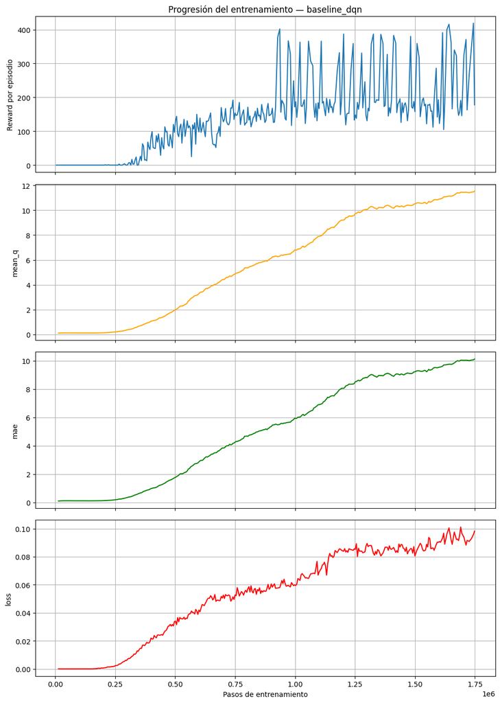

```python
generate_training_graphs('baseline_dqn')
```

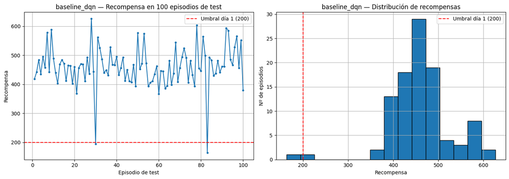

```
Media: 461.29
% episodios ≥ 200: 98.0%
```

```python
generate_test_graphs('baseline_dqn')
```

Las gráficas correspondientes al modelo Baseline DQN muestran una evolución positiva a lo largo del entrenamiento. La recompensa obtenida aumenta de forma progresiva tras las primeras etapas de exploración, lo que indica que el agente va aprendiendo una estrategia cada vez más eficaz para desenvolverse en el entorno. Aunque tanto la función de pérdida como los valores Q presentan pequeñas oscilaciones, este comportamiento es habitual en los algoritmos DQN y no impide que el entrenamiento converja hacia una política estable.

Los resultados de la evaluación confirman este comportamiento, alcanzando una recompensa media de aproximadamente 461 puntos, muy por encima del mínimo exigido para la práctica.

#### Double DQN

```
dict_keys(['loss', 'mae', 'mean_q', 'mean_eps', 'episode_reward', 'nb_episode_steps', 'nb_steps', 'episode', 'duration'])
Episodios registrados: 394
```

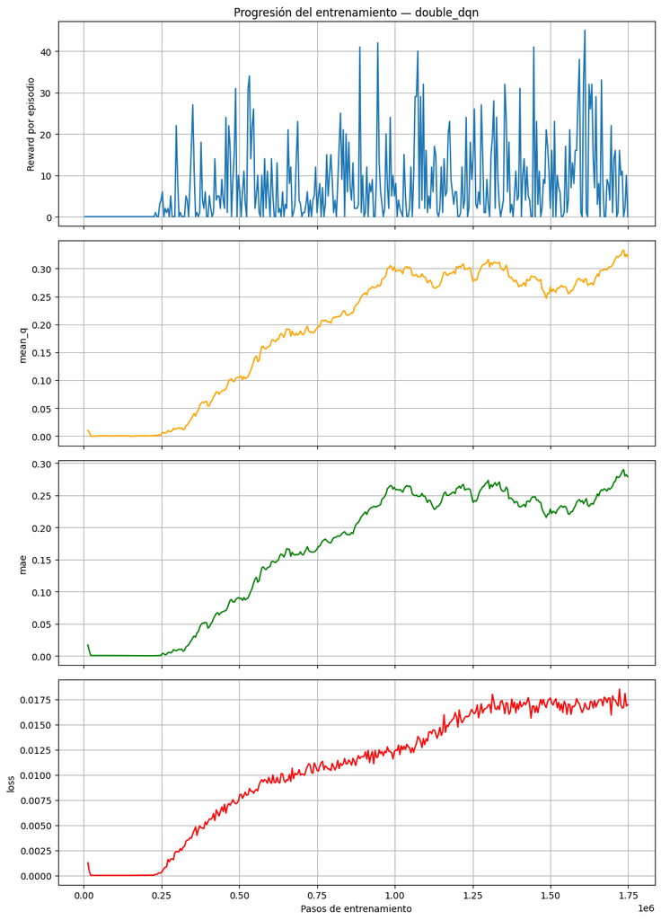

```python
generate_training_graphs('double_dqn')
```

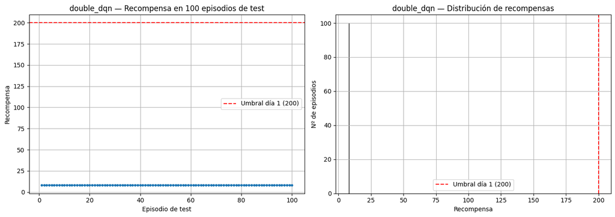

```
Media: 8.00
% episodios ≥ 200: 0.0%
```

```python
generate_test_graphs('double_dqn')
```

En el caso de Double DQN, las gráficas muestran un comportamiento muy diferente al observado en el modelo Baseline. La recompensa apenas aumenta durante el entrenamiento y el agente no consigue mejorar de forma significativa su rendimiento. El modelo terminó el entrenamiento con un mean_q muy bajo, cercano a 0.32, en comparación con el Baseline DQN que alcanzó un valor de 11.46, lo que demuestra que la variante Double no ha logrado propagar correctamente las recompensas futuras durante el entrenamiento. Esto se refleja también en la evaluación final, donde obtiene una recompensa media cercana a 8 puntos.

Aunque Double DQN está diseñado para reducir la sobreestimación de los valores Q, en este experimento la configuración utilizada no ha permitido que el agente aprenda una estrategia eficaz.

#### Dueling DQN

```
dict_keys(['loss', 'mae', 'mean_q', 'mean_eps', 'episode_reward', 'nb_episode_steps', 'nb_steps', 'episode', 'duration'])
Episodios registrados: 316
```

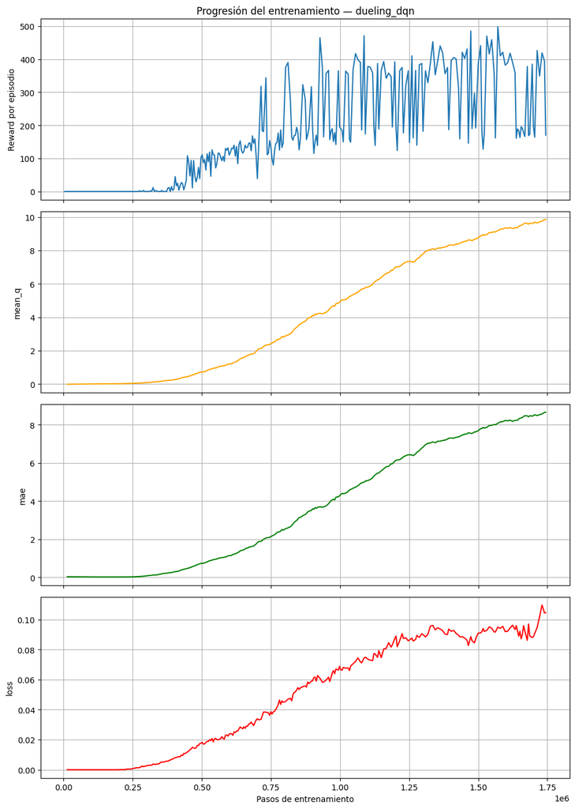

```python
generate_training_graphs('dueling_dqn')
```

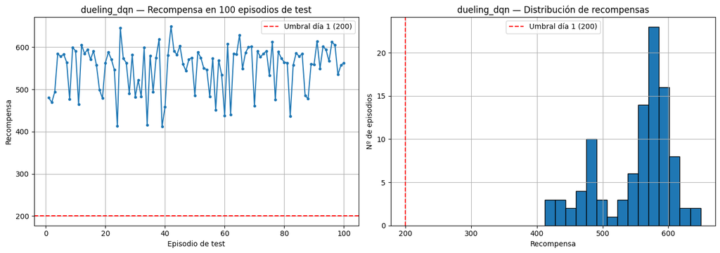

```
Media: 551.04
% episodios ≥ 200: 100.0%
```

```python
generate_test_graphs('dueling_dqn')
```

Estos resultados sugieren que la arquitectura Dueling DQN se adapta especialmente bien al entorno Enduro, ya que permite aprender de forma más eficiente el valor de cada estado y diferenciar mejor qué acciones aportan una mayor ventaja en cada situación.

#### Gráficas comparativas

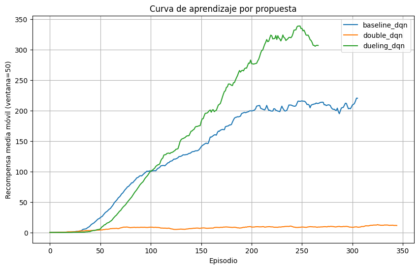

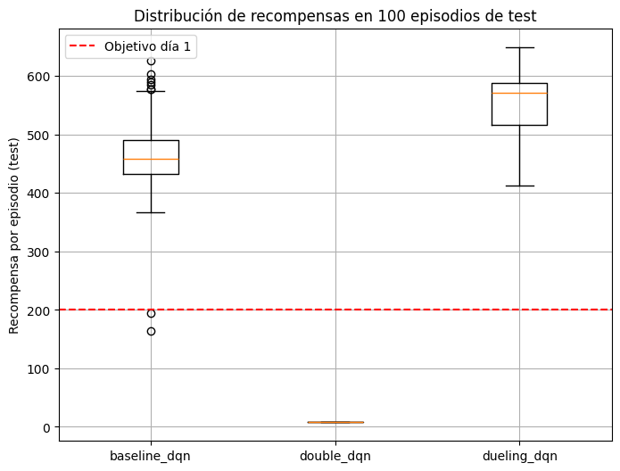

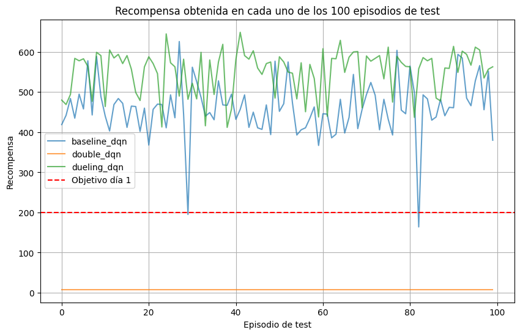

```python
import matplotlib.pyplot as plt

# 1. Curva de aprendizaje (recompensa media móvil durante el entrenamiento)
histories = {
    'baseline_dqn': f'dqn_Enduro-v0_baseline_dqn_log_{run_timestamps["baseline_dqn"]}.json',
    'double_dqn': f'dqn_Enduro-v0_double_dqn_log_{run_timestamps["double_dqn"]}.json',
    'dueling_dqn': f'dqn_Enduro-v0_dueling_dqn_log_{run_timestamps["dueling_dqn"]}.json',
}
plt.figure(figsize=(10, 6))
for name, log_file in histories.items():
    with open(log_file) as f:
        log_data = json.load(f)
    rewards = log_data['episode_reward']
    window = 50
    moving_avg = np.convolve(rewards, np.ones(window)/window, mode='valid')
    plt.plot(moving_avg, label=name)
plt.xlabel('Episodio')
plt.ylabel('Recompensa media móvil (ventana=50)')
plt.title('Curva de aprendizaje por propuesta')
plt.legend()
plt.grid(True)
plt.show()

# 2. Distribución de recompensas en test (boxplot)
test_results = {
    'baseline_dqn': f'test_results_baseline_dqn_{run_timestamps["baseline_dqn"]}.json',
    'double_dqn': f'test_results_double_dqn_{run_timestamps["double_dqn"]}.json',
    'dueling_dqn': f'test_results_dueling_dqn_{run_timestamps["dueling_dqn"]}.json',
}
results = {}
for name, test_file in test_results.items():
    with open(test_file) as f:
        test_data = json.load(f)
    results[name] = test_data[name]['rewards']
    REWARD_THRESHOLD = test_data[name]['threshold']
plt.figure(figsize=(8, 6))
plt.boxplot([results[name] for name in results], labels=list(results.keys()))
plt.axhline(REWARD_THRESHOLD, color='red', linestyle='--', label='Objetivo día 1')
plt.ylabel('Recompensa por episodio (test)')
plt.title('Distribución de recompensas en 100 episodios de test')
plt.legend()
plt.grid(True)
plt.show()

# 3. Recompensa por episodio de test (comparación directa)
plt.figure(figsize=(10, 6))
for name in results:
    plt.plot(results[name], label=name, alpha=0.7)
plt.axhline(REWARD_THRESHOLD, color='red', linestyle='--', label='Objetivo día 1')
plt.xlabel('Episodio de test')
plt.ylabel('Recompensa')
plt.title('Recompensa obtenida en cada uno de los 100 episodios de test')
plt.legend()
plt.grid(True)
plt.show()
```

En las gráficas comparativas se pueden ver claramente las diferencias de rendimiento entre las tres variantes implementadas.

En conjunto, estos resultados indican que la arquitectura Dueling DQN es la que mejor se adapta al entorno Enduro de las alternativas analizadas.

### Conclusiones

En este proyecto se ha implementado y evaluado un agente de Aprendizaje por Refuerzo basado en DQN para el entorno Enduro-v0, comparando tres variantes de la arquitectura: DQN estándar, Double DQN y Dueling DQN.

Los resultados obtenidos muestran que las mejoras introducidas en un algoritmo no garantizan por sí solas un mejor rendimiento si no van acompañadas de un ajuste adecuado de los hiperparámetros y del proceso de entrenamiento. En nuestro caso, la versión Double DQN no consiguió aprender una política eficaz, obteniendo una recompensa media de únicamente 8 puntos en la fase de evaluación. Este comportamiento indica que el agente no llegó a converger correctamente y pone de manifiesto la importancia de ajustar parámetros como la exploración, la tasa de aprendizaje o el número de pasos de entrenamiento.

Por el contrario, tanto DQN estándar como Dueling DQN lograron superar ampliamente el umbral mínimo establecido para la práctica (200 puntos). El modelo DQN alcanzó una recompensa media cercana a los 461 puntos, demostrando una política estable y capaz de completar con éxito el primer día de carrera en la mayoría de los episodios de prueba. La arquitectura Dueling DQN mostró un rendimiento aún más sólido, obteniendo recompensas superiores de forma consistente durante la evaluación, lo que confirma la utilidad de separar la estimación del valor del estado y de la ventaja de cada acción en este tipo de entornos.

En conjunto, los resultados permiten concluir que la arquitectura Dueling DQN ha sido la alternativa más eficaz para resolver el problema planteado, ofreciendo un aprendizaje más robusto y un comportamiento más estable que las otras variantes evaluadas. Además, el desarrollo de este proyecto ha permitido comprender de forma práctica el funcionamiento de los algoritmos DQN y comprobar cómo pequeñas modificaciones en la arquitectura o en la estrategia de aprendizaje pueden tener un impacto significativo en el rendimiento final del agente.